# Lecture 4 - Binomial and Normal distributions

Author: Matthew J. Cossley

Last update: 25 April, 2022

## Learning objectives

- Define and understand **Bernoulli** random variables.
- Define and understand **Binomial** random variables.
- Define and understand **Normal** random variables.
- Understand how, in principle, to **compute expected values** from continuous and discrete random variables.
- Define and understand **probability distributions** including **probability mass functions**, and **probability density functions**, **cumulative probability functions** and **quantile functions**.
- Be able to read simple expected values and probabilities from probability mass and density functions, and cumulative distribution functions.
- Understand the **central limit theorem** and the **distribution of sample means** and how it depends on sample size.
- Use `R` functions to obtain useful things about binomial and normal distributions.
  - `dbinom`
  - `pbinom`
  - `qbinom`
  - `rbinom`
  - `dnorm`
  - `pnorm`
  - `qnorm`
  - `rnorm`

## Bernoulli random variable

### Definition

A single sample from a any random variable that produces a dichotomous outcome is formally defined as a *Bernoulli* trial. To be a Bernoulli trial, a few conditions must be met:

1. Each trial yields one of the two outcomes usually called success ($S$) and failure ($F$).
2. For each trial, the probability of success $P(S)$ is the same and is denoted by $p = P(S)$. The probability of failure is then $q = P(F) = 1 - P(S)$ for each trial.
3. Trials are **independent**. The probability of success in a trial does not change given any amount of information about the outcomes of other trials.

Bernoulli random variables are completely defined by the single parameter $p = P(S)$. If $X$ is a Bernoulli random variable then we would write:

$X \sim Bernoulli(p)$

### Probability distribution

The probability distribution of a Bernoulli random variable is very simple. We simply need to indicate two probabilities as follows.

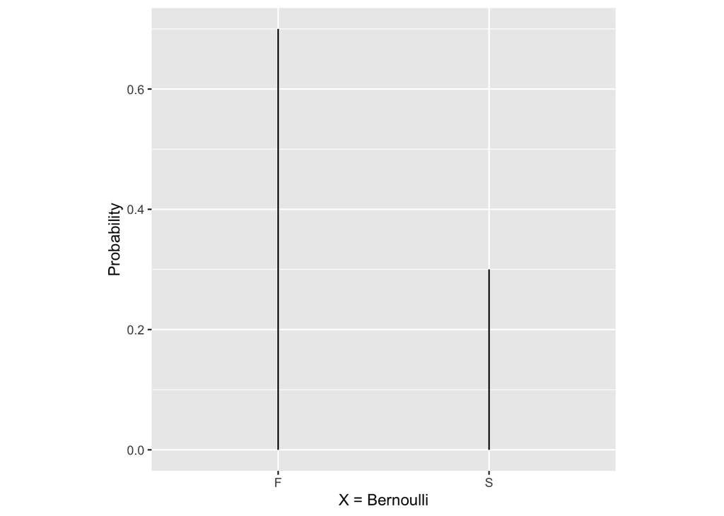

## Binomial random variable

### Definition

Consider a fixed number $n$ of Bernoulli trials conducted with success probability $P(S)=p$ and failure probability $P(F)=q=1-p$ in each trial. Define the random variable $X$ as follows:

$X =$ the sum of the number of Successes from $n$ of the above Bernoulli trials.

Then $X$ is called a binomial distribution with $n$ trials and success probability $p$. The binomial distribution is completely defined by two parameters, $n$ and $p$, and we can write:

$X \sim Binomial(n,p)$

### Probability distribution

#### Population parameters: n=2, p=0.5

Define the random variable $X$ as follows:

$X$ = the number of *heads* in $2$ flips of a *fair* coin.

Then $X \sim Binomial(n=2, p=0.5)$

To obtain the probability distribution, we must compute the probability of every possible outcome that $X$ can produce. With $n=2$ flips, it is easy to see that there are 3 possible outcomes (0, 1, or 2 heads) which are obtained with the following possible events and corresponding probabilities:

$$\begin{align}
P(X=0) &= P(TT) \\
&= P(T)P(T) \\
&= 0.5 \times 0.5 \\
&= 0.25 \\\\
P(X=1) &= P(TH) + P(HT) \\
&= P(T)P(H) + P(H)P(T) \\
&= 0.5 \times 0.5 + 0.5 \times 0.5 \\
&= 0.25 + 0.25 \\
&= 0.5 \\\\
P(X=2) &= P(HH) \\
&= P(H)P(H) \\
&= 0.5 \times 0.5 \\
&= 0.25
\end{align}$$

Above, we were able to write $P(TT)=P(T)P(T)$ because coin flips are statistically **independent**.

In simple cases like this it’s no big deal to compute the probabilities or all possible events by hand, but this approach quickly becomes intractable in real world situations. Luckily, `R` provides functions for essentially all the probability distributions you will likely ever find yourself using. In the case of a binomial distribution, we will use the `dbinom()` function as illustrated below.

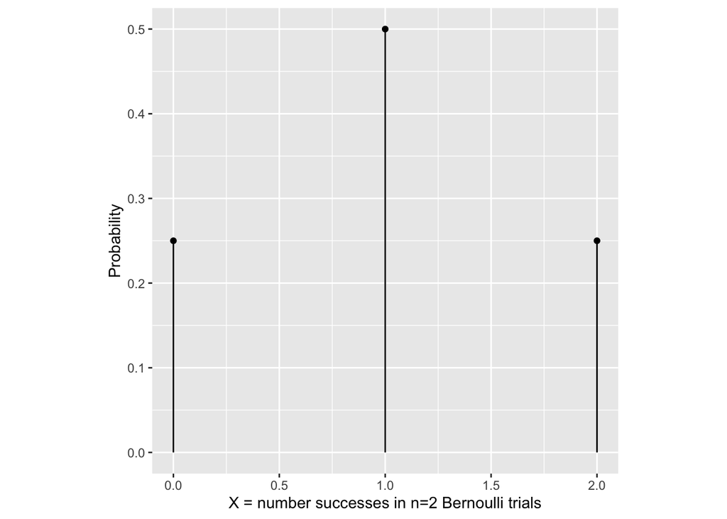

#### Population parameters: function of n and p

Now lets run through this exercise with different $n$ and $p$ values. Below, notice that when $p=0.1$, the distribution is skewed to the left. This makes sense because if the probability of success is very small, then the probability of achieving zero or only few successes is high. Similarly, notice that when $p=0.9$, the distribution is skewed to the right. The same logic applied in the previous sentence applies here. If the probability of success is very high, then we should expect many successes, and most of the probability will correspond to larger outcomes.

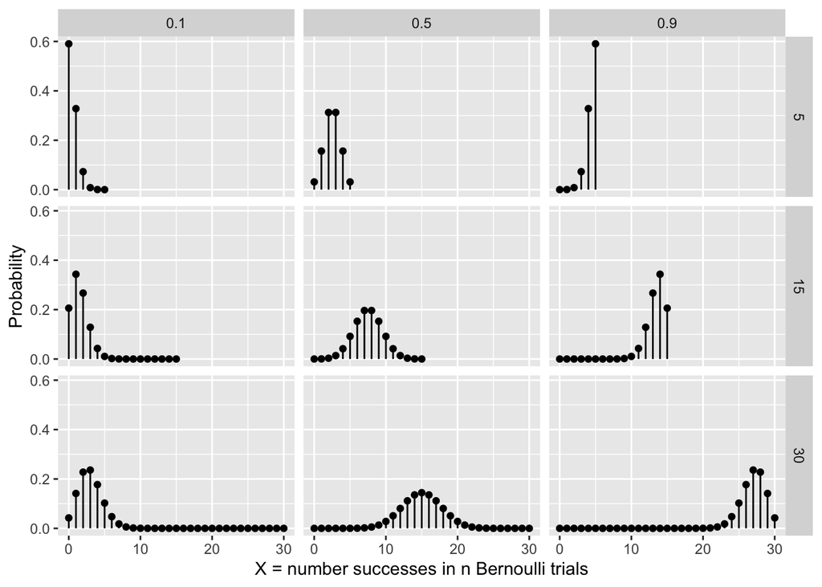

## Normal distribution

The normal distribution is defined by two parameters:

- $\mu$: population mean
- $\sigma$: population standard deviation

It is just a quirk of the normal distribution that the parameters that define it correspond to its mean and standard deviation. This will not generally be true for most other distributions that we will deal with.

### Probability distribution

The normal distribution is continuous, and the continuous probability distributions are called probability density functions (pdfs).

The following equation defines the pdf of a normal distribution:

$$f(x) = \frac{1}{\sigma \sqrt{2\pi}} e^{-\frac{1}{2}{\frac{(x - \mu)^2}{\sigma}}}$$

#### The standard normal (Z)

The *standard normal* distribution is a normal distribution with zero mean and unit variance ($\mu=0$, $\sigma^2=1$). It is also called the $Z$ distribution. It looks like this:

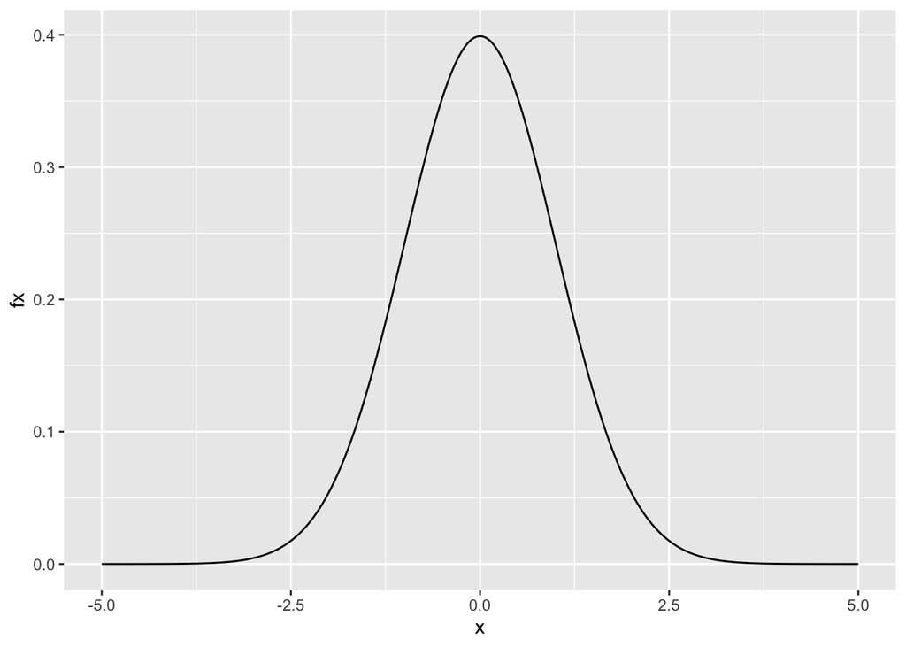

#### Normal distribution with different parameters

Lets have a look at how the normal distribution changes with different mean and variance.

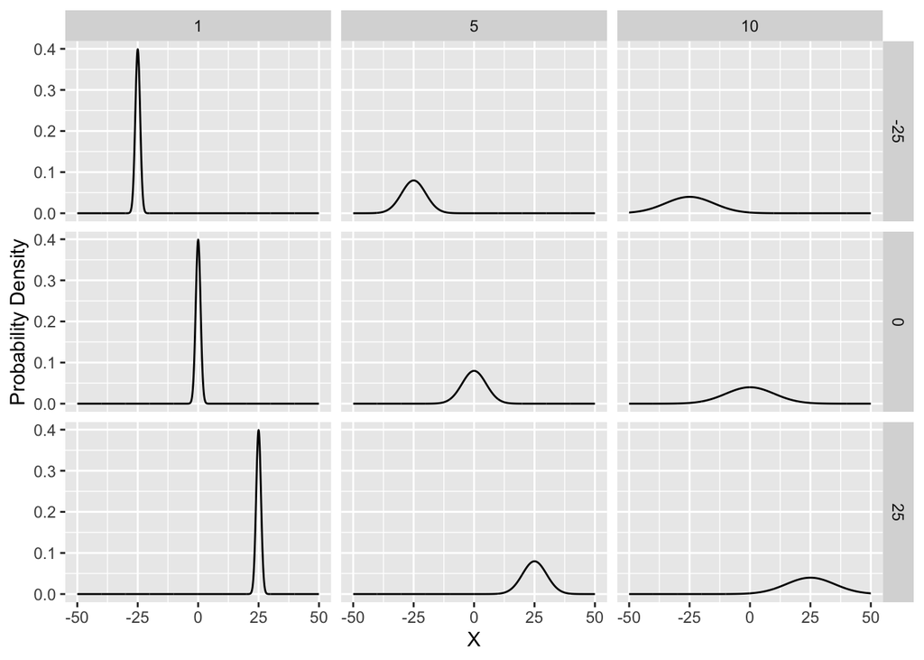

## Computing Probabilities

With discrete probability distribution, we were able to compute the probability of certain events by counting the total number of ways for an outcome to occur and dividing by the total number of possible outcomes. However, for *continuous* probability distributions, this methods doesn’t work. To see this, consider a Normal distribution. We first need to count the number of ways for an outcome to occur. Suppose we are interested in $p(x<1)$. How many ways are there for $x$ to be less than $1$? Since $x$ is continuous, there are *infinite* ways for this occur! What about the total number of possible outcomes? Right. Infinity again. So we are left dividing one infinity by another infinity. Quite a confusing and ill-defined situation.

### Discrete distributions

With discrete probability distributions – also called probability mass functions (pmfs) – finite and well-defined probabilities exist for every single possible outcome. This means that you can plot the distribution, and read probabilities right off the y-axis of the plot.

#### Binomial pmf

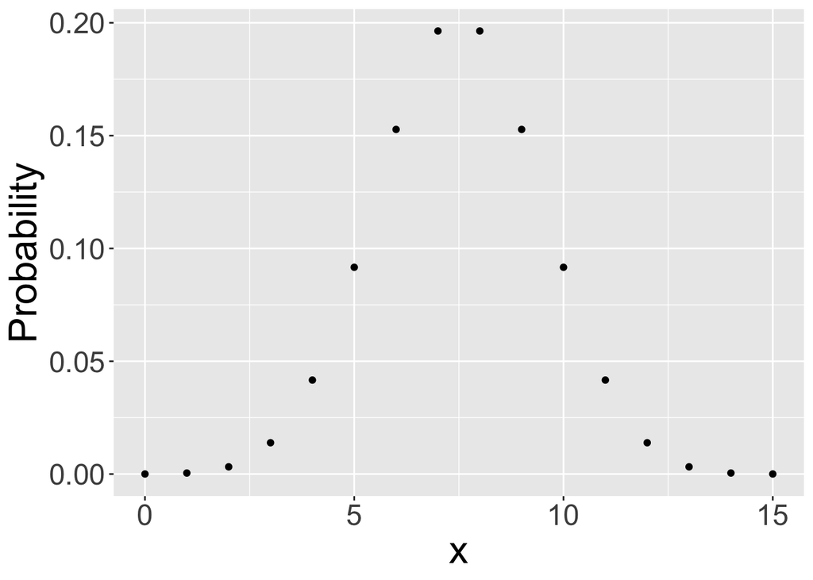

### Continuous distributions

With continuous probability distributions – aslo called probability density functions (pdfs) – the probability of any single outcome is zero. The distribution represents *probability density* rather than probability. In this case, probability is computed by taking the area under the curve.

#### Normal pdf

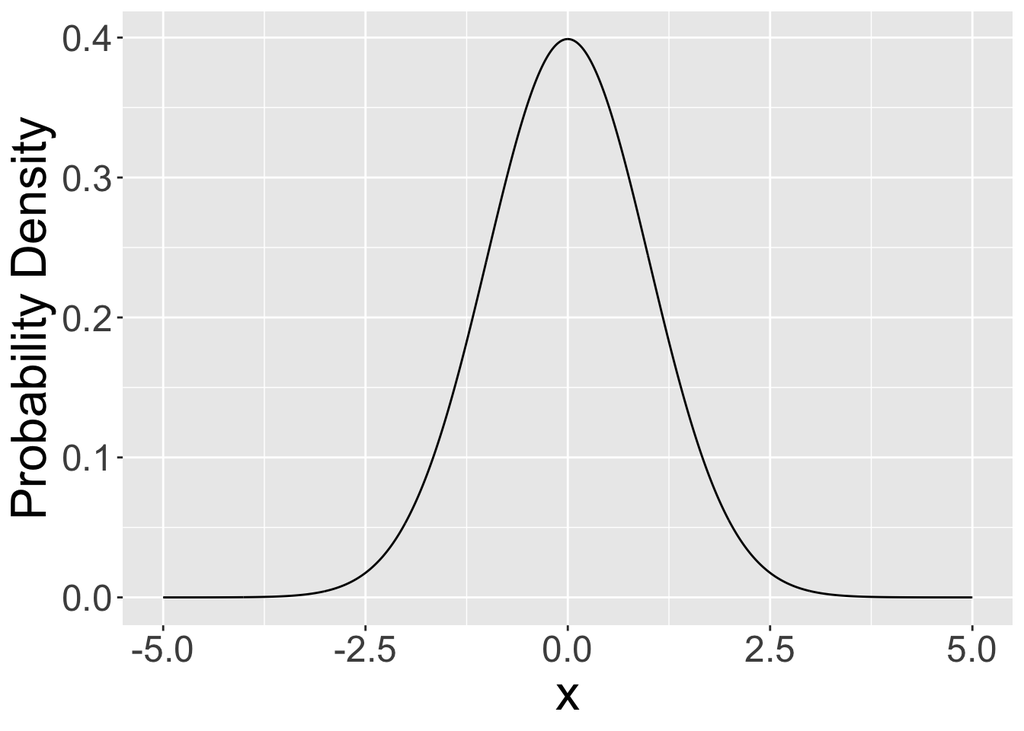

#### Binomial example: P(X < 8)

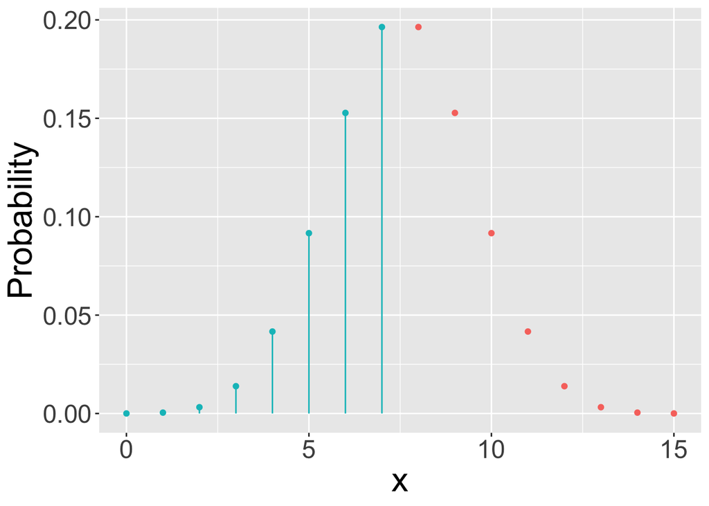

$$p(X<8) = \sum_{i=0}^7 p(x_{i})$$

#### Normal example: P(X < 1)

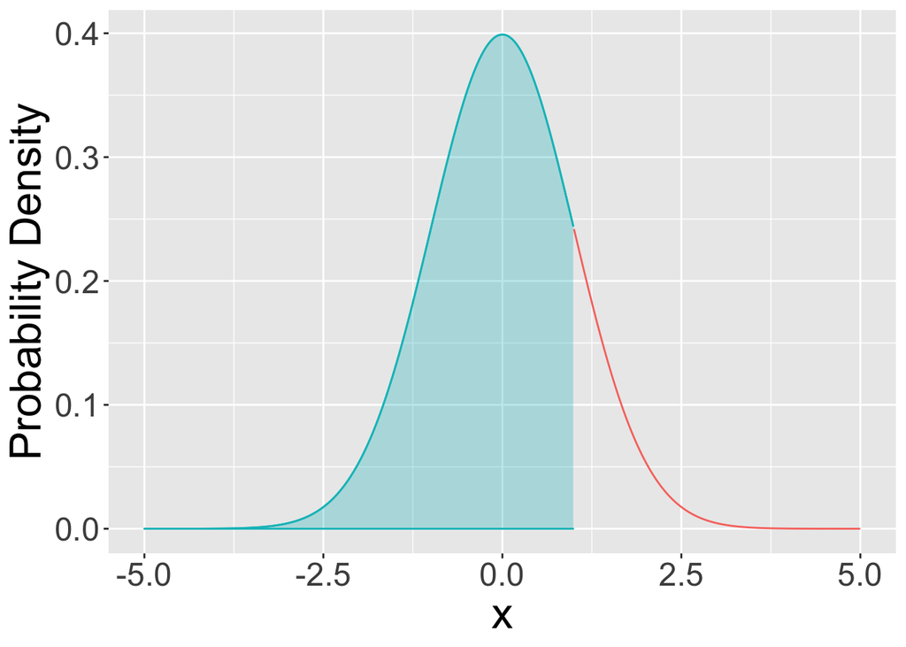

$$p(X<1) = \int_{-\inf}^{1} f(x) dx$$

### Using R to compute probabilities

For most probability distributions, R has 4 built-in functions that tell you almost everything you will ever want to know about them.

For the Binomial distribution, these functions are the following:

- `dbinom(x)`: Probability mass function
- `pbinom(x)`: Cumulative distribution function
- `qbinom(p)`: quantile function
- `rbinom(n)`: function for random samples

For the Normal distributions, these functions are the following:

- `dnorm(x)`: Probability density function
- `pnorm(x)`: Cumulative distribution function
- `qnorm(p)`: quantile function
- `rnorm(n)`: function for random samples

You can see the naming convention adopted by R right away.

- The `d` functions are mass or density functions.
  - For discrete distributions, these functions return $P(X=x)$. E.g., `dbinom(x, n, p)` returns the probability that a binomial random variable with parameters $n$ and $p$ will yield a value of $x$.
  - For continuous distributions, these functions return a probability density. To get probability, we must consider a range of outcomes $[a, b]$ and compute the area under the curve. Computing the exact area under the curve requires evaluating an integral, which is too hard for us and awkward to do using a `d` function. It will be best to use a `p` function in this case (see below).
- The `p` functions are cumulative probability functions.
  - By default these functions return $P(X \leq x)$. If you specify `lower.tail=FALSE` then these functions return $P(X>x)$. Be careful when using these functions to appreciate that for continuous distributions $P(X \leq x)=1-P(X \geq x)$ but for discrete distributions $P(X \leq x)=1-P(X \geq x+1)$. All that is basically just to say be careful when considering whether to use greater than or greather than and equal to etc.
- The `q` functions are quantile functions.
  - They are the inverse of the cumulative probability functions. Here, you specify a cumulative probability $q$, and the function returns the value of $x$ such that $P(X<x)=q$.
- The `r` functions generate random samples.

**pmf**: probabilities are given by values on the y-axis.

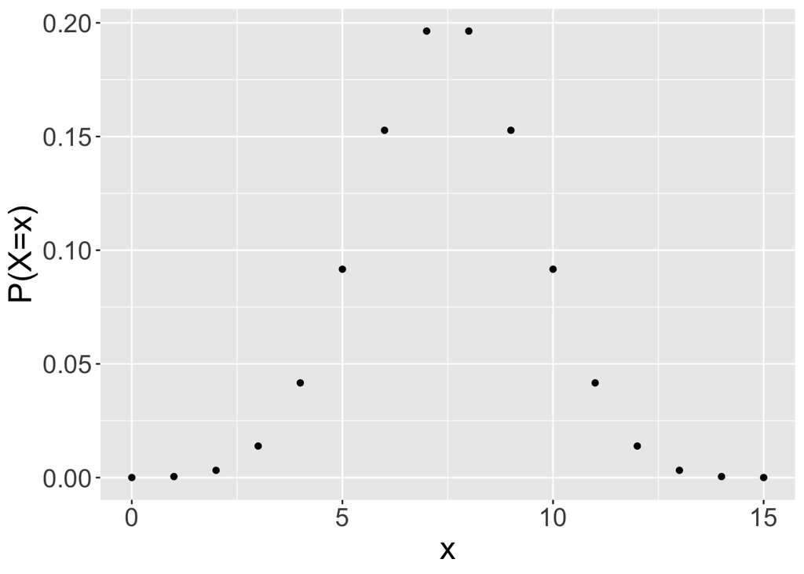

**cdf**: cumulative probabilities (X<x) are given by reading values on the y-axis.

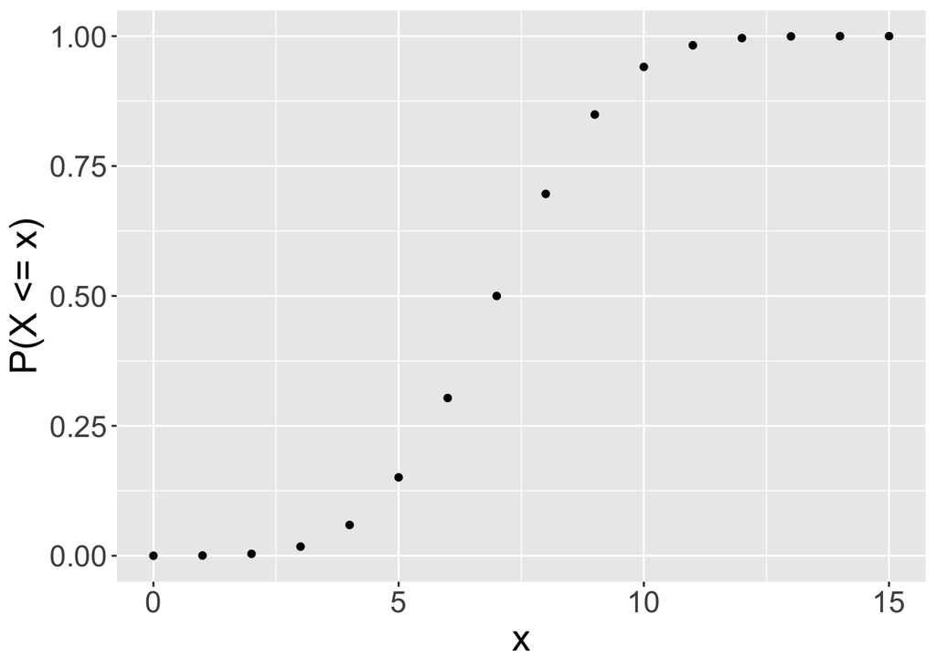

**qf**: use this function to specify a probability (x-axis) and get the value that satisfies this probability from the y-axis.

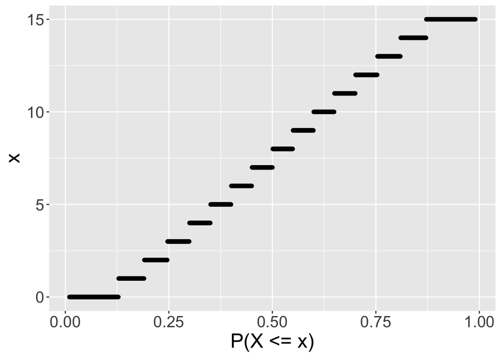

**pdf**: probabilities are given by the area under the curve.

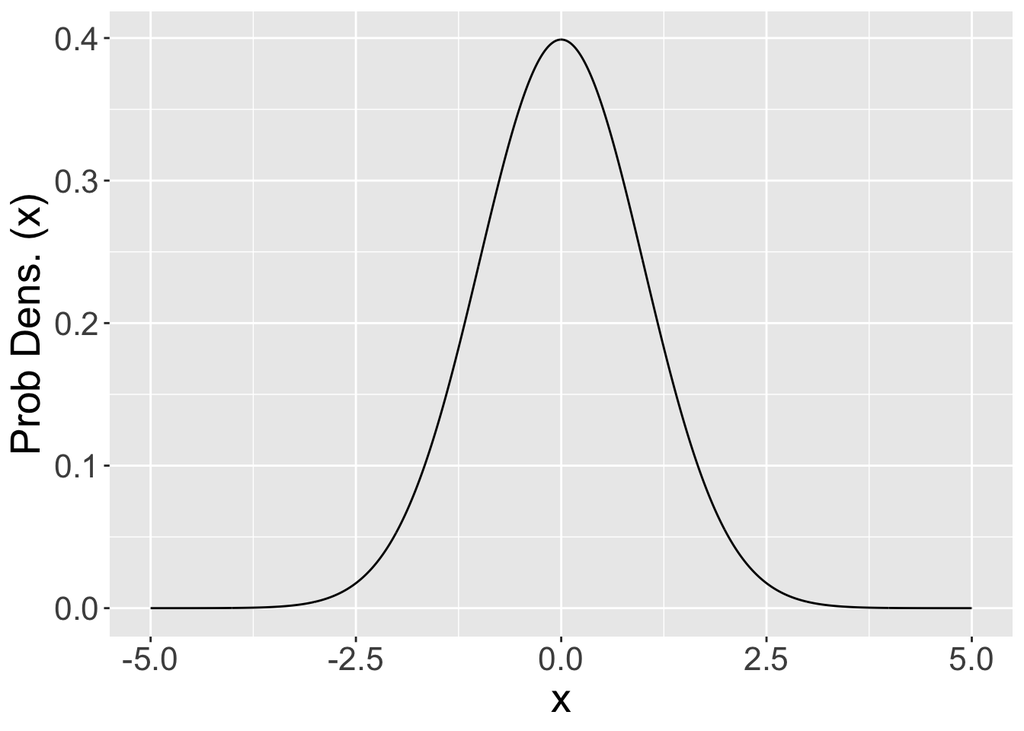

**cdf**: cumulative probabilities (X<x) are given by reading values on the y-axis.

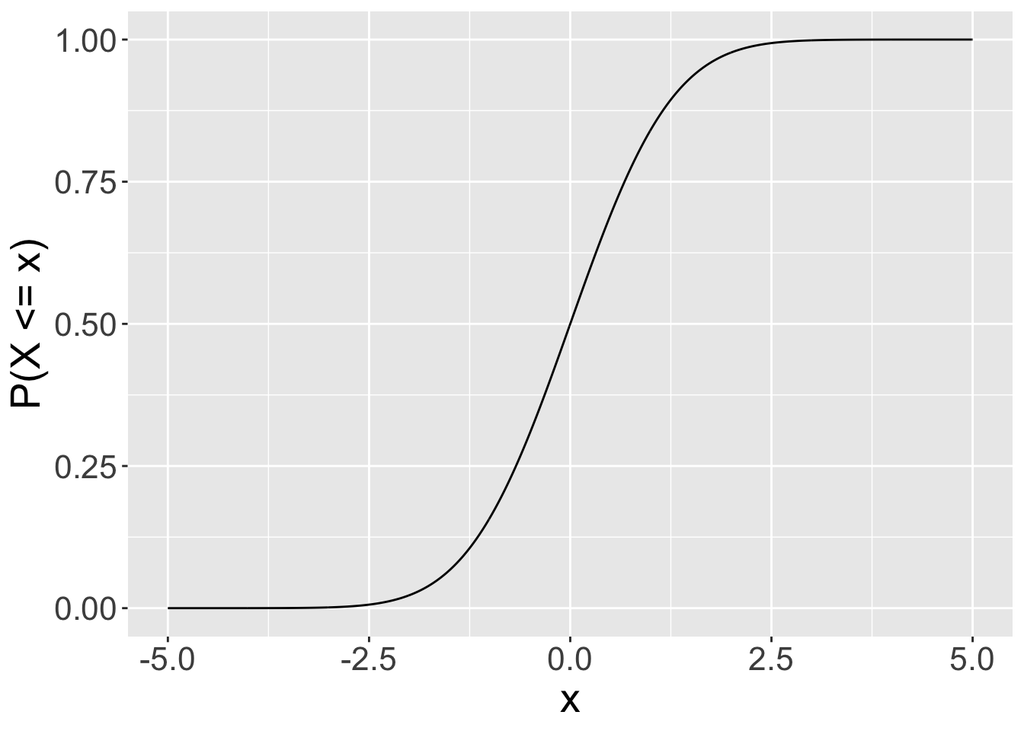

**qf**: use this function to specify a probability (x-axis) and get the value that satisfies this probability from the y-axis.

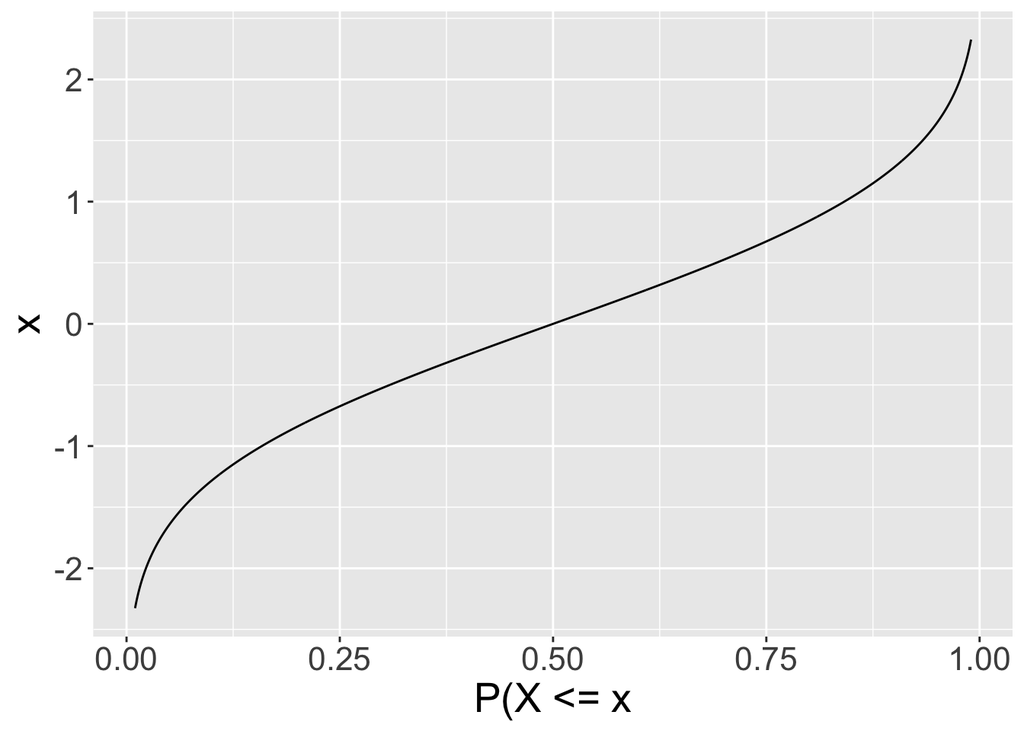

**In general, I think it is important for you to be able to read each of the types of plots above, so please really try to encode these and think about them deeply.**

#### Binomial example: P(X < 8)

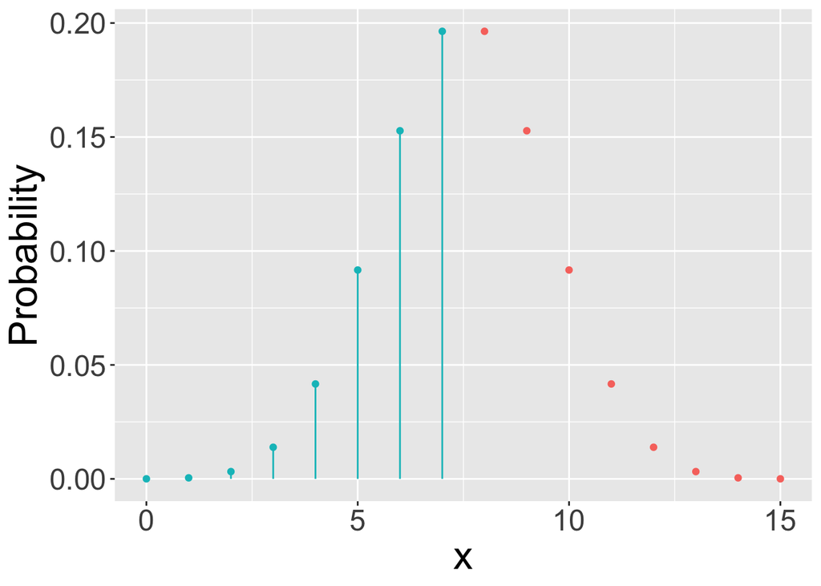

```r
n <- 15
p <- 0.5

## Using pmf (exact)
px <- sum(dbinom(0:7, n, p))
px
## [1] 0.5

## using cdf (exact)
px <- pbinom(7, n, p)
px
## [1] 0.5
```

#### Normal example: P(X < 1)

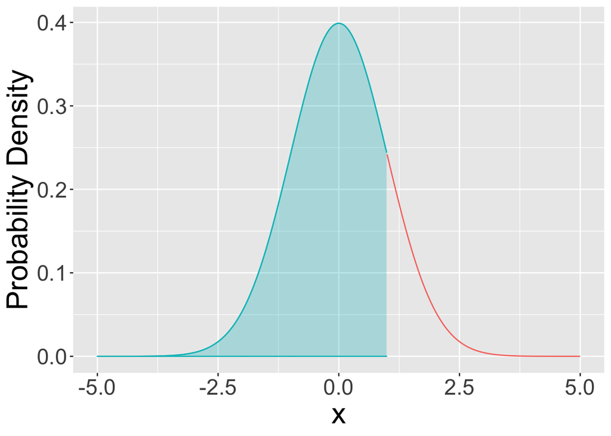

```r
mu <- 0
sig <- 1

## Using pdf (not exact)
px <- sum(dnorm(seq(-5, 1, .1), mu, sig)*.1)
px
## [1] 0.8532414

## using cdf (exact)
px <- pnorm(1, mu, sig)
px
## [1] 0.8413447
```

#### Binomial example: P(X > 9)

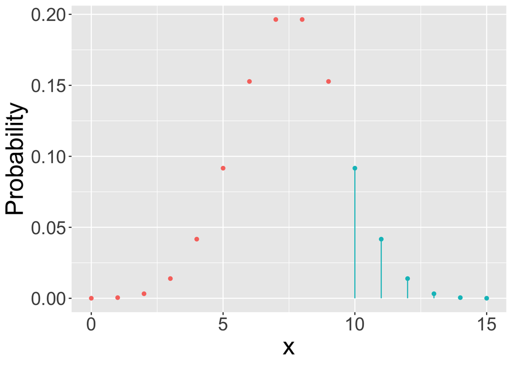

```r
n <- 15
p <- 0.5

## Using pmf (exact)
px <- sum(dbinom(10:n, n, p))
px
## [1] 0.1508789

## using cdf (exact)
px <- pbinom(9, n, p, lower.tail=F)
px
## [1] 0.1508789
```

#### Normal example: P(X > 1.8)

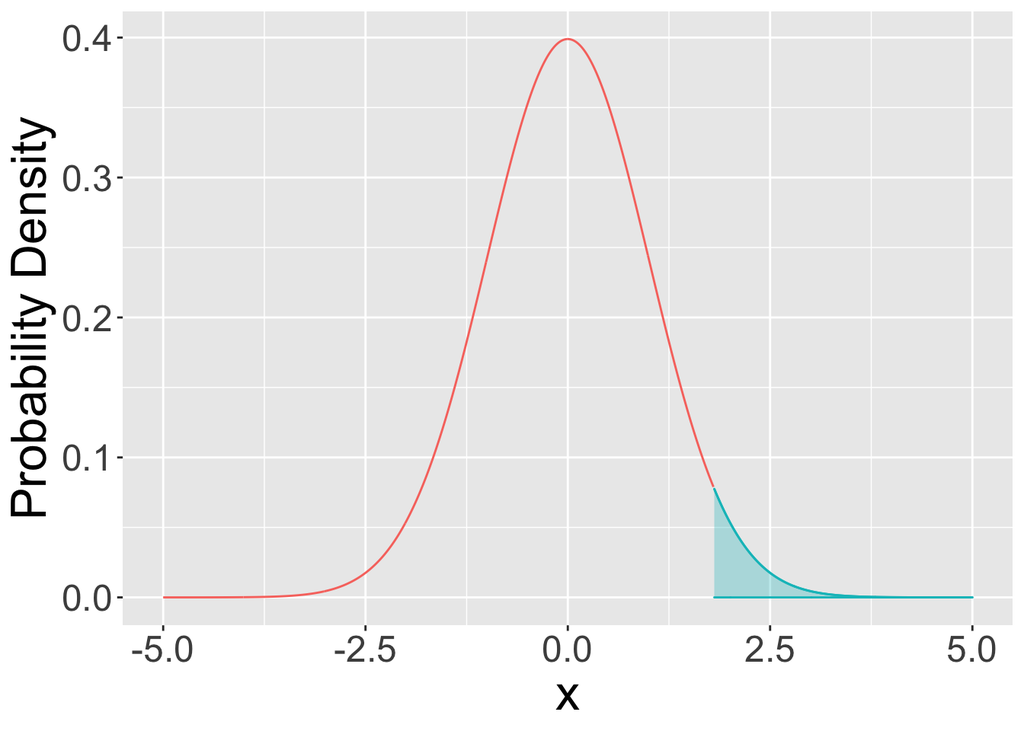

```r
mu <- 0
sig <- 1

## Using pdf (not exact)
p <- sum(dnorm(seq(1.8, 5, .1), mu, sig)*.1)
p
## [1] 0.03999603

## using cdf (exact)
p <- pnorm(1.8, mu, sig, lower.tail=F)
p
## [1] 0.03593032
```

## Distribution of sample means

- Every time we draw a sample from any random variable, we can compute the sample mean of that sample.
- In general, if we repeat that procedure many times, we will see that every time we draw a sample, we get different outcomes and therefore different sample means.
- This means that the sample mean is itself a random variable (i.e., because every time you measure it you get a different number).
- Lets examine this by considering samples from the Binomial random variable with distribution shown in the left column of the following, and samples from the Normal random variable with distribution shown on the right.
- More precisely, consider the following:

$X \sim \mathcal{Binomial}(n=10, p=0.5)$

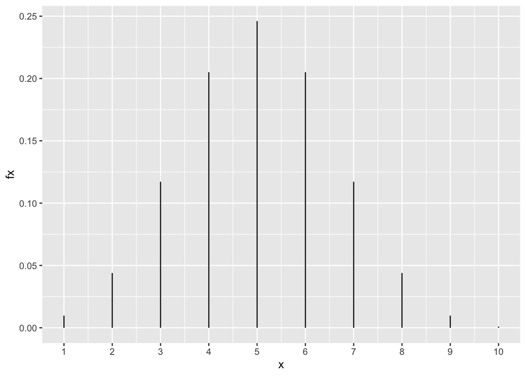

```
##     sample_number sample_outcome sample_mean
##  1:      sample_1              5         5.2
##  2:      sample_1              3         5.2
##  3:      sample_1              5         5.2
##  4:      sample_1              7         5.2
##  5:      sample_1              5         5.2
##  6:      sample_1              5         5.2
##  7:      sample_1              8         5.2
##  8:      sample_1              7         5.2
##  9:      sample_1              4         5.2
## 10:      sample_1              3         5.2
## 11:      sample_2              3         4.4
## 12:      sample_2              6         4.4
## 13:      sample_2              6         4.4
## 14:      sample_2              6         4.4
```

[output cut: 17 more lines]

$Y \sim \mathcal{N}({\mu=5, \sigma=2.5})$

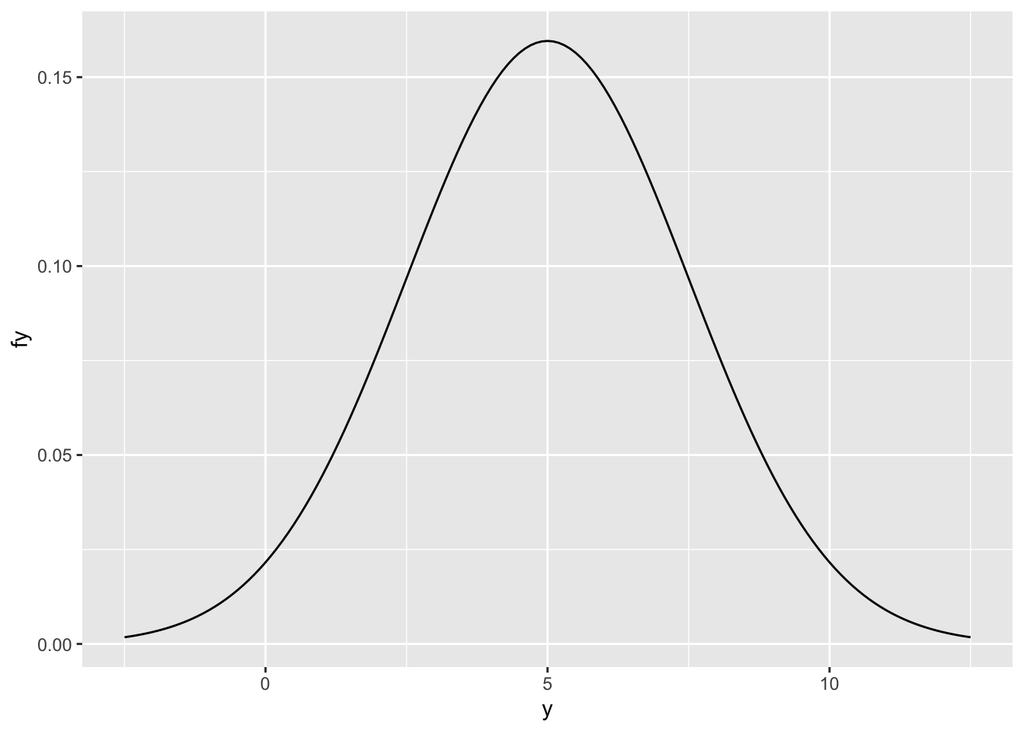

```
##     sample_number sample_outcome sample_mean
##  1:      sample_1     9.39058620    4.971204
##  2:      sample_1     0.95918452    4.971204
##  3:      sample_1     7.75762009    4.971204
##  4:      sample_1     1.19216393    4.971204
##  5:      sample_1     5.61459033    4.971204
##  6:      sample_1     7.51498823    4.971204
##  7:      sample_1     3.80830107    4.971204
##  8:      sample_1     1.73085407    4.971204
##  9:      sample_1     2.14050179    4.971204
## 10:      sample_1     9.60324679    4.971204
## 11:      sample_2     0.01036751    5.470851
## 12:      sample_2     8.82726952    5.470851
## 13:      sample_2     5.83175350    5.470851
## 14:      sample_2     8.67550648    5.470851
```

[output cut: 17 more lines]

We see that every time we sample from either random variable:

1. We get a sample mean $\bar{\boldsymbol{x}}$ that is close to the population mean $\mu$, but doesn’t match it exactly unless by dumb luck.
2. Every sample from $X$ leads to a different value for $\bar{\boldsymbol{x}}$.
3. Thus, we have verified that $\bar{\boldsymbol{x}}$ must itself be a random variable.

Moving forward, we will denote the random variable corresponding to the distribution of sample means with the symbol $\bar{X}$, and continue to use $\bar{\boldsymbol{x}}$ to refer to a particular sample mean.

$$\begin{align}
X & \rightarrow \{x_{1}, \ldots, x_{n}\} \\
\\
\bar{X} & \rightarrow \frac{1}{n} \{ x_{1} + \ldots + x_{n} \}
\end{align}$$

- Notice that $n>1$ samples from $X$ are needed to generate a single $n=1$ sample from $\bar{X}$.
- This means that in order to estimate the distribution of sample means, we need to draw $n>1$ samples from $X$ many times.

If we perform an experiment in which we draw $n=10$ samples from $X$ or from $Y$, compute the sample means for each ($\bar{x}$ and $\bar{y}$), and repeat 500 times, then we get the following estimate for the distribution of sample means:

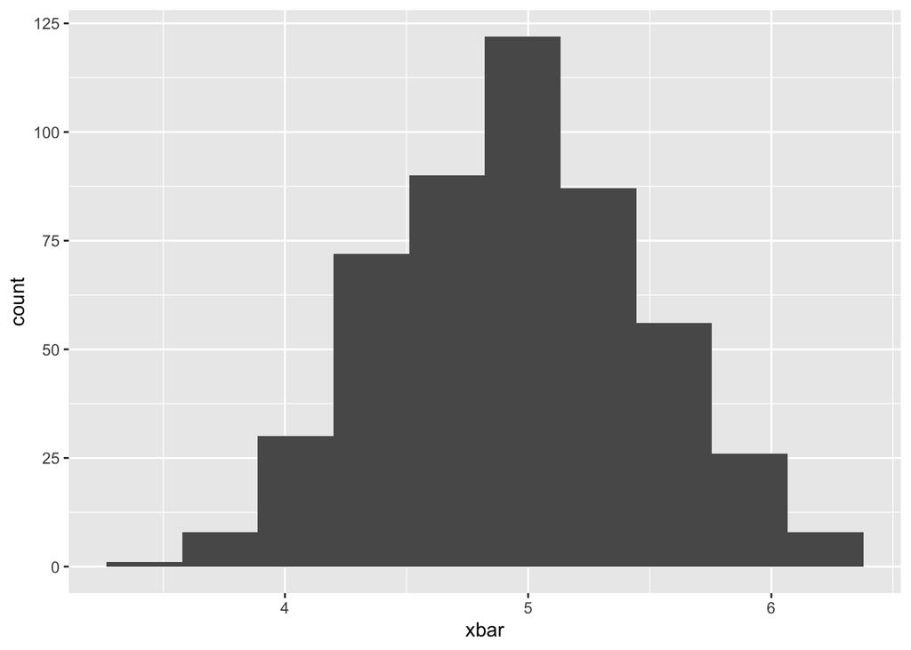

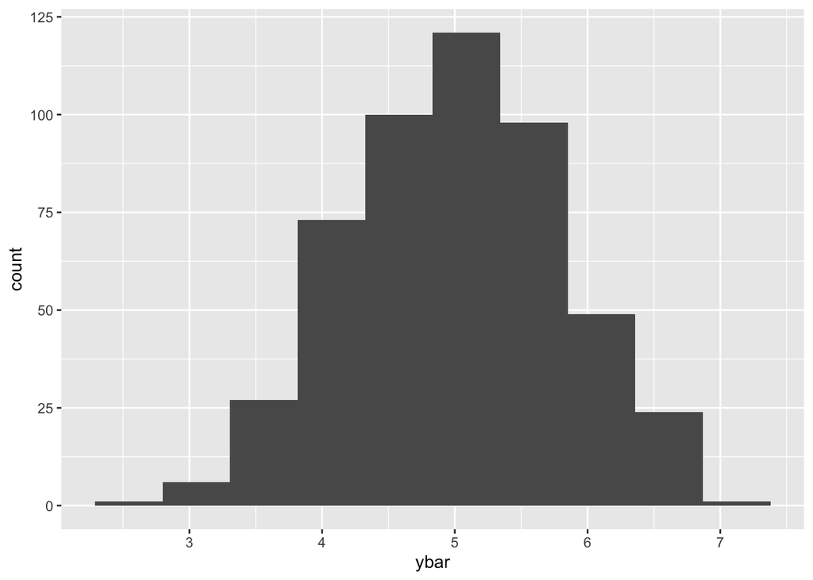

Note that even though $X$ is discrete, $\bar{X}$ is continuous. We also note that both $\bar{X}$ and $\bar{Y}$ look bell-shaped. This is because of something called the *central limit theorem*. Before we say more about this very important theorem, lets investigate how the original distributions ($X$ and $Y$) compare to their corresponding distributions of sample means ($\bar{X}$ and $\bar{Y}$) in terms of central tendancy and spread.

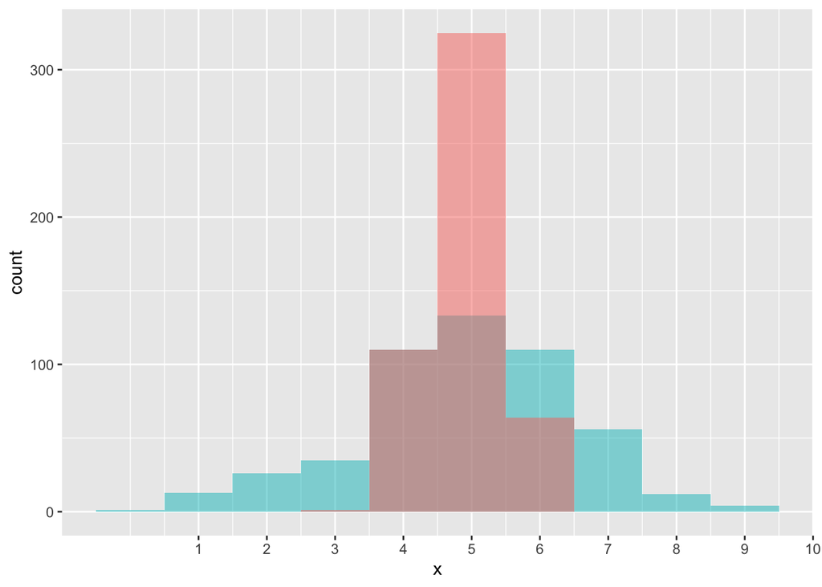

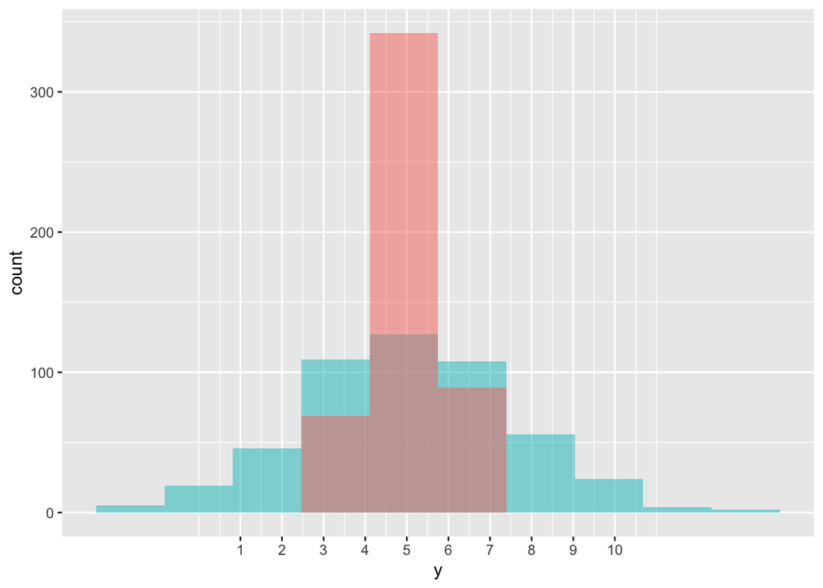

We can see a few important things from these plots:

- The central tendancy (i.e., mean) of the distribution of sample means $\bar{X}$ looks to be about the same as that for the original distribution $X$.
- The spread of the distribution of sample means $\bar{X}$ looks to be smaller than that for the original distribution $X$.

The central limit theorem helps us formalise both of these observations.

## Central limit theorem

The **central limit theorem** tells us that the sum of independent and identically distributed random variables approximates a Normal distribution.

Let

$\boldsymbol{Y} = \boldsymbol{X}_1 + \boldsymbol{X}_2 + \dots + \boldsymbol{X}_n$

and

$\boldsymbol{X}_i \sim \boldsymbol{D}$

where $\boldsymbol{D}$ can have any distribution whatsoever. Then,

$\boldsymbol{Y} \sim \mathcal{N}(\mu_{Y}, \sigma_{y}^2)$

### Central limit theorem mean and variance

One way to see where the mean and variance parameters come from in the central limit theorem is to use the following rule:

Let

$Y \sim a X + b$

Then:

$\mathbb{E}\big[Y\big] = a \mathbb{E}\big[X\big] + E(b)$

$\mathbb{Var}\big[Y\big] = (a^2) \mathbb{Var}\big[X\big]$

### Applied to the distribution of sample sums

$$\begin{align}
\boldsymbol{Y} &= \boldsymbol{X}_1 + \boldsymbol{X}_2 + \dots + \boldsymbol{X}_n \\
\\
E(\boldsymbol{Y}) &= E(\boldsymbol{X}_1 + \boldsymbol{X}_2 + \dots + \boldsymbol{X}_n) \\
&= E(\boldsymbol{X}_1) + E(\boldsymbol{X}_2) + \dots + E(\boldsymbol{X}_n) \\
&= \mu_x + \mu_x + \ldots + \mu_x \\
&= n \mu_x \\
\\
Var(\boldsymbol{Y}) &= Var(\boldsymbol{X}_1 + \boldsymbol{X}_2 + \dots + \boldsymbol{X}_n) \\
&= Var(\boldsymbol{X}_1) + Var(\boldsymbol{X}_2) + \dots + Var(\boldsymbol{X}_n) \\
&= \sigma_x^2 + \sigma_x^2 + \dots + \sigma_x^2 \\
&= n \sigma_x^2 \\
\end{align}$$

$$\begin{align}
\mu_{Y} &= n \mu_{X} \\
\sigma_Y^2 &= n \sigma_X^2 \\
\end{align}$$

### Applied to the distribution of sample means

$$\begin{align}
\boldsymbol{Y} &= \frac{1}{n} (\boldsymbol{X}_1 + \boldsymbol{X}_2 + \dots + \boldsymbol{X}_n) \\
\\
E(\boldsymbol{Y}) &= E(\frac{1}{n} (\boldsymbol{X}_1 + \boldsymbol{X}_2 + \dots + \boldsymbol{X}_n)) \\
&= \frac{1}{n}
(E(\boldsymbol{X}_1) + E(\boldsymbol{X}_2) + \dots + E(\boldsymbol{X}_n)) \\
&= \frac{1}{n} (\mu_x + \mu_x + \ldots + \mu_x) \\
&= \mu_x \\
\\
Var(\boldsymbol{Y}) &= Var(\frac{1}{n} (\boldsymbol{X}_1 + \boldsymbol{X}_2 + \dots + \boldsymbol{X}_n)) \\
&= Var(\frac{1}{n^2} (Var(\boldsymbol{X}_1) + Var(\boldsymbol{X}_2) + \dots + Var(\boldsymbol{X}_n)) \\
&= \frac{1}{n^2} ( \sigma_x^2 + \sigma_x^2 + \dots + \sigma_x^2 ) \\
&= \frac{1}{n} \sigma_x^2 \\
\end{align}$$

$$\begin{align}
\mu_{Y} &= \mu_{X} \\
\sigma_Y^2 &= \frac{1}{n} \sigma_X^2 \\
\end{align}$$

### Standard Error

When applying the central limit theorem to the distribution of sample means, we get:

$$\begin{align}
\mu_{Y} &= \mu_{X} \\
\sigma_Y^2 &= \frac{1}{n} \sigma_X^2 \\
\end{align}$$

When expressed in terms of standard deviation:

$$\begin{align}
\mu_{Y} &= \mu_{X} \\
\sigma_y &= \frac{1}{\sqrt{n}} \sigma_X \\
\end{align}$$

Here, $\sigma_Y$ is called the **standard error of the mean (SEM)** and it is very commonly used to draw error bars on various plots.